# Internet Privacy Poll

Mohammed Ali

July 1, 2018

# Loading and Summarizing the Dataset

How many people participated in the poll?

```r
Poll <- as_tibble(read.csv("./data/AnonymityPoll.csv"))
glimpse(Poll)
```

```
## Observations: 1,002
## Variables: 13
## $ Internet.Use           <int> 1, 1, 0, 1, 0, 1, 1, 0, 0, 1, 0, 1, 0, ...
## $ Smartphone             <int> 0, 0, 1, 0, NA, 1, 0, 0, NA, 0, 0, 1, 0...
## $ Sex                    <fct> Male, Male, Female, Male, Female, Male,...
## $ Age                    <int> 62, 45, 70, 70, 80, 49, 52, 76, 75, 76,...
## $ State                  <fct> Massachusetts, South Carolina, New Jers...
## $ Region                 <fct> Northeast, South, Northeast, South, Sou...
## $ Conservativeness       <int> 4, 1, 4, 4, 4, 4, 3, 3, 4, 4, 4, 3, 5, ...
## $ Info.On.Internet       <int> 0, 1, 0, 3, NA, 6, 3, NA, NA, 0, NA, 1,...
## $ Worry.About.Info       <int> 1, 0, 0, 1, NA, 0, 1, NA, NA, 0, NA, 0,...
## $ Privacy.Importance     <dbl> 100.00000, 0.00000, NA, 88.88889, NA, 8...
## $ Anonymity.Possible     <int> 0, 1, 0, 1, NA, 1, 0, NA, NA, 1, NA, 0,...
## $ Tried.Masking.Identity <int> 0, 0, 0, 0, NA, 1, 0, NA, NA, 0, NA, 0,...
## $ Privacy.Laws.Effective <int> 0, 1, NA, 0, NA, 0, 1, NA, 0, 1, 0, 0, ...
```

How many interviewees responded that they use a smartphone? How many interviewees responded that they don’t use a smartphone?

```r
table(Poll$Smartphone)
```

```
##
##   0   1
## 472 487
```

How many interviewees did not respond to the question, resulting in a missing value, or NA, in the summary() output?

```r
summary(Poll$Smartphone)
```

```
##    Min. 1st Qu.  Median    Mean 3rd Qu.    Max.    NA's
##  0.0000  0.0000  1.0000  0.5078  1.0000  1.0000      43
```

Which of the following are states in the Midwest census region? Which was the state in the South census region with the largest number of interviewees?

```r
table( Poll$State, Poll$Region)
```

```
##
##                        Midwest Northeast South West
##   Alabama                    0         0    11    0
##   Arizona                    0         0     0   24
##   Arkansas                   0         0    10    0
##   California                 0         0     0  103
##   Colorado                   0         0     0   19
##   Connecticut                0         8     0    0
##   Delaware                   0         0     6    0
##   District of Columbia       0         0     2    0
##   Florida                    0         0    42    0
##   Georgia                    0         0    34    0
##   Idaho                      0         0     0    8
##   Illinois                  32         0     0    0
##   Indiana                   27         0     0    0
##   Iowa                      14         0     0    0
##   Kansas                    14         0     0    0
##   Kentucky                   0         0    25    0
##   Louisiana                  0         0    17    0
##   Maine                      0         4     0    0
##   Maryland                   0         0    18    0
##   Massachusetts              0        19     0    0
##   Michigan                  31         0     0    0
##   Minnesota                 15         0     0    0
##   Mississippi                0         0    11    0
##   Missouri                  26         0     0    0
##   Montana                    0         0     0    5
##   Nebraska                  11         0     0    0
##   Nevada                     0         0     0    8
##   New Hampshire              0         7     0    0
##   New Jersey                 0        16     0    0
##   New Mexico                 0         0     0    5
##   New York                   0        60     0    0
##   North Carolina             0         0    32    0
##   North Dakota               5         0     0    0
##   Ohio                      38         0     0    0
##   Oklahoma                   0         0    14    0
##   Oregon                     0         0     0   20
##   Pennsylvania               0        45     0    0
##   Rhode Island               0         4     0    0
##   South Carolina             0         0    12    0
##   South Dakota               3         0     0    0
##   Tennessee                  0         0    17    0
##   Texas                      0         0    72    0
##   Utah                       0         0     0   11
##   Vermont                    0         3     0    0
##   Virginia                   0         0    31    0
##   Washington                 0         0     0   28
##   West Virginia              0         0     5    0
##   Wisconsin                 23         0     0    0
##   Wyoming                    0         0     0    7
```

# Internet and Smartphone Users

How many interviewees reported not having used the Internet and not having used a smartphone? How many interviewees reported having used the Internet and having used a smartphone? How many interviewees reported having used the Internet but not having used a smartphone? How many interviewees reported having used a smartphone but not having used the Internet?

```r
table(Poll$Smartphone, Poll$Internet.Use)
```

```
##
##       0   1
##   0 186 285
##   1  17 470
```

How many interviewees have a missing value for their Internet use?

```r
summary(Poll$Internet.Use)
```

```
##    Min. 1st Qu.  Median    Mean 3rd Qu.    Max.    NA's
##  0.0000  1.0000  1.0000  0.7742  1.0000  1.0000       1
```

How many interviewees have a missing value for their smartphone use?

```r
summary(Poll$Smartphone)
```

```
##    Min. 1st Qu.  Median    Mean 3rd Qu.    Max.    NA's
##  0.0000  0.0000  1.0000  0.5078  1.0000  1.0000      43
```

Use the subset function to obtain a data frame called `limited`, which is limited to interviewees who reported Internet use or who reported smartphone use.

How many interviewees are in the new data frame?

```r
limited <- Poll %>% filter(Smartphone == 1 | Internet.Use == 1)
glimpse(limited)
```

```
## Observations: 792
## Variables: 13
## $ Internet.Use           <int> 1, 1, 0, 1, 1, 1, 1, 1, 1, 1, 1, 1, 1, ...
## $ Smartphone             <int> 0, 0, 1, 0, 1, 0, 0, 1, 1, 0, 0, 0, 1, ...
## $ Sex                    <fct> Male, Male, Female, Male, Male, Female,...
## $ Age                    <int> 62, 45, 70, 70, 49, 52, 76, 50, 47, 69,...
## $ State                  <fct> Massachusetts, South Carolina, New Jers...
## $ Region                 <fct> Northeast, South, Northeast, South, Sou...
## $ Conservativeness       <int> 4, 1, 4, 4, 4, 3, 4, 3, 3, 3, NA, 5, 4,...
## $ Info.On.Internet       <int> 0, 1, 0, 3, 6, 3, 0, 1, 0, 9, 0, 5, 0, ...
## $ Worry.About.Info       <int> 1, 0, 0, 1, 0, 1, 0, 0, 0, 0, 1, 1, 0, ...
## $ Privacy.Importance     <dbl> 100.00000, 0.00000, NA, 88.88889, 88.88...
## $ Anonymity.Possible     <int> 0, 1, 0, 1, 1, 0, 1, 0, 1, 0, NA, NA, 0...
## $ Tried.Masking.Identity <int> 0, 0, 0, 0, 1, 0, 0, 0, 0, 0, 0, 0, 0, ...
## $ Privacy.Laws.Effective <int> 0, 1, NA, 0, 0, 1, 1, 0, 0, 0, 0, 0, 1,...
```

# Summarizing Opinions about Internet Privacy

Which variables have missing values in the limited data frame?

```r
summary(limited)
```

```
##   Internet.Use      Smartphone         Sex           Age
##  Min.   :0.0000   Min.   :0.0000   Female:392   Min.   :18.00
##  1st Qu.:1.0000   1st Qu.:0.0000   Male  :400   1st Qu.:33.00
##  Median :1.0000   Median :1.0000                Median :51.00
##  Mean   :0.9785   Mean   :0.6308                Mean   :48.57
##  3rd Qu.:1.0000   3rd Qu.:1.0000                3rd Qu.:62.00
##  Max.   :1.0000   Max.   :1.0000                Max.   :93.00
##                   NA's   :20                    NA's   :22
##             State           Region    Conservativeness Info.On.Internet
##  California    : 89   Midwest  :172   Min.   :1.000    Min.   : 0.000
##  Texas         : 57   Northeast:128   1st Qu.:3.000    1st Qu.: 2.000
##  New York      : 45   South    :288   Median :3.000    Median : 4.000
##  Pennsylvania  : 33   West     :204   Mean   :3.237    Mean   : 3.795
##  Florida       : 32                   3rd Qu.:4.000    3rd Qu.: 6.000
##  North Carolina: 28                   Max.   :5.000    Max.   :11.000
##  (Other)       :508                   NA's   :45
##  Worry.About.Info Privacy.Importance Anonymity.Possible
##  Min.   :0.0000   Min.   :  0.00     Min.   :0.0000
##  1st Qu.:0.0000   1st Qu.: 41.43     1st Qu.:0.0000
##  Median :0.0000   Median : 68.75     Median :0.0000
##  Mean   :0.4886   Mean   : 62.85     Mean   :0.3692
##  3rd Qu.:1.0000   3rd Qu.: 88.89     3rd Qu.:1.0000
##  Max.   :1.0000   Max.   :100.00     Max.   :1.0000
##  NA's   :2        NA's   :5          NA's   :39
##  Tried.Masking.Identity Privacy.Laws.Effective
##  Min.   :0.0000         Min.   :0.0000
##  1st Qu.:0.0000         1st Qu.:0.0000
##  Median :0.0000         Median :0.0000
##  Mean   :0.1633         Mean   :0.2559
##  3rd Qu.:0.0000         3rd Qu.:1.0000
##  Max.   :1.0000         Max.   :1.0000
##  NA's   :8              NA's   :65
```

What is the average number of pieces of personal information on the Internet, according to the Info.On.Internet variable?

```r
summary(limited$Info.On.Internet)
```

```
##    Min. 1st Qu.  Median    Mean 3rd Qu.    Max.
##   0.000   2.000   4.000   3.795   6.000  11.000
```

How many interviewees reported a value of 0 for Info.On.Internet? How many interviewees reported the maximum value of 11 for Info.On.Internet?

```r
table(limited$Info.On.Internet)
```

```
##
##   0   1   2   3   4   5   6   7   8   9  10  11
## 105  84  95 101 104  94  67  63  40  18  13   8
```

What proportion of interviewees who answered the Worry.About.Info question worry about how much information is available about them on the Internet?

```r
sum(limited$Worry.About.Info, na.rm = TRUE) / nrow(limited)
```

```
## [1] 0.4873737
```

What proportion of interviewees who answered the Anonymity.Possible question think it is possible to be completely anonymous on the Internet?

```r
summary(limited$Anonymity.Possible)
```

```
##    Min. 1st Qu.  Median    Mean 3rd Qu.    Max.    NA's
##  0.0000  0.0000  0.0000  0.3692  1.0000  1.0000      39
```

What proportion of interviewees who answered the Tried.Masking.Identity question have tried masking their identity on the Internet?

```r
summary(limited$Tried.Masking.Identity)
```

```
##    Min. 1st Qu.  Median    Mean 3rd Qu.    Max.    NA's
##  0.0000  0.0000  0.0000  0.1633  0.0000  1.0000       8
```

What proportion of interviewees who answered the Privacy.Laws.Effective question find United States privacy laws effective?

```r
summary(limited$Privacy.Laws.Effective)
```

```
##    Min. 1st Qu.  Median    Mean 3rd Qu.    Max.    NA's
##  0.0000  0.0000  0.0000  0.2559  1.0000  1.0000      65
```

# Relating Demographics to Polling Results

Often, we are interested in whether certain characteristics of interviewees (e.g. their age or political opinions) affect their opinions on the topic of the poll (in this case, opinions on privacy). In this section, we will investigate the relationship between the characteristics Age and Smartphone and outcome variables Info.On.Internet and Tried.Masking.Identity, again using the limited data frame we built in an earlier section of this problem.

Build a histogram of the age of interviewees. What is the best represented age group in the population?

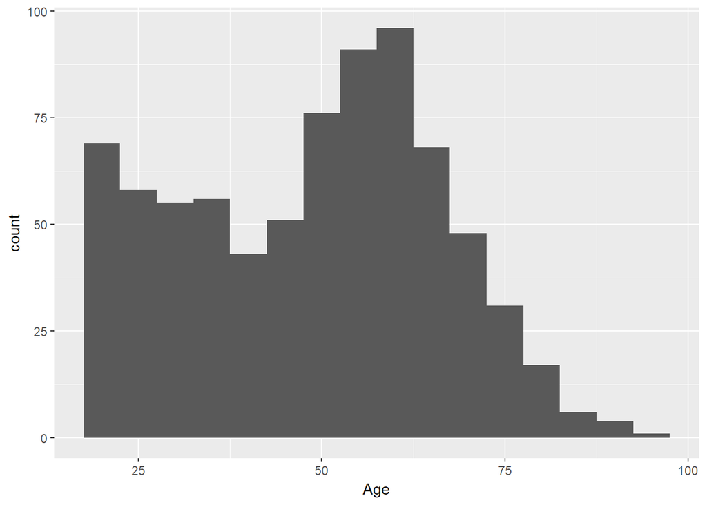

```r
ggplot(limited, aes(Age)) +
  geom_histogram(binwidth = 5)
```

What is the largest number of interviewees that have exactly the same value in their Age variable AND the same value in their Info.On.Internet variable?

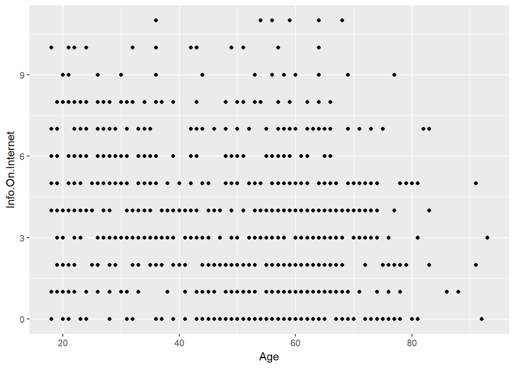

```r
ggplot(limited, aes(x = Age, y = Info.On.Internet)) +
  geom_point()
```

What is the average Info.On.Internet value for smartphone users? What is the average Info.On.Internet value for non-smartphone users?

```r
tapply(limited$Info.On.Internet, limited$Smartphone, mean)
```

```
##        0        1
## 2.922807 4.367556
```

What proportion of smartphone users who answered the Tried.Masking.Identity question have tried masking their identity when using the Internet?

What proportion of non-smartphone users who answered the Tried.Masking.Identity question have tried masking their identity when using the Internet?

```r
tapply(limited$Tried.Masking.Identity, limited$Smartphone, summary)
```

```
## $`0`
##    Min. 1st Qu.  Median    Mean 3rd Qu.    Max.    NA's
##  0.0000  0.0000  0.0000  0.1174  0.0000  1.0000       4
##
## $`1`
##    Min. 1st Qu.  Median    Mean 3rd Qu.    Max.    NA's
##  0.0000  0.0000  0.0000  0.1925  0.0000  1.0000       4
```